# plasma storage project - data wrangling

Savannah Weaver

2023

# Packages

```r
if (!require("tidyverse")) install.packages("tidyverse")
```

```r
library("tidyverse") # workflow and plots
if (!require("rmdformats")) install.packages("rmdformats")
library("rmdformats") # clean html R markdown format
```

# Background and Goals

Blood was drawn from several *Crotalus oreganus* in May 2023, the blood plasma was pooled, then we ran an experiment to test the effect of different plasma storage methods on plasma osmolality. Plasma osmolality was measured on a VAPRO vapor pressure osmometer in 3 replicates. In this R script, I check the distribution of replicates, omit outliers, and average remaining replicates.

# Load Data

```r
# load data
osml_reps_wide <- read.csv("./data/plasma_osmolality_raw.csv",
                na.strings = c("","NA"),
                header = TRUE
                )

# put into tidy format and format new data cols
osml_reps <- gather(osml_reps_wide,
                    key = "replicate_no",
                    value = "osmolality_mmol_kg",
                    4:6) %>%
  mutate(
    sample_ID = as.factor(sample_ID),
    replicate_no = as.factor(replicate_no),
    osmolality_mmol_kg = as.numeric(osmolality_mmol_kg)
  )

# check
summary(osml_reps_wide)
```

```
##  date_osmom_run     time_osmom_run      sample_ID              rep1
##  Length:85          Length:85          Length:85          Min.   :314.0
##  Class :character   Class :character   Class :character   1st Qu.:327.0
##  Mode  :character   Mode  :character   Mode  :character   Median :333.0
##                                                           Mean   :338.9
##                                                           3rd Qu.:346.0
##                                                           Max.   :426.0
##
##       rep2            rep3        Entered.by         Checked.by
##  Min.   :313.0   Min.   :310.0   Length:85          Length:85
##  1st Qu.:322.0   1st Qu.:321.0   Class :character   Class :character
##  Median :333.0   Median :330.5   Mode  :character   Mode  :character
##  Mean   :335.3   Mean   :335.6
##  3rd Qu.:340.0   3rd Qu.:344.0
##  Max.   :426.0   Max.   :435.0
##                  NA's   :1
##       X
##  Length:85
##  Class :character
##  Mode  :character
##
##
##
##
```

```r
summary(osml_reps)
```

```
##  date_osmom_run     time_osmom_run         sample_ID    Entered.by
##  Length:255         Length:255         0-1      :  3   Length:255
##  Class :character   Class :character   0-2      :  3   Class :character
##  Mode  :character   Mode  :character   0-3      :  3   Mode  :character
##                                        0-4      :  3
##                                        0-5      :  3
##                                        push-FM-1:  3
##                                        (Other)  :237
##   Checked.by             X             replicate_no osmolality_mmol_kg
##  Length:255         Length:255         rep1:85      Min.   :310.0
##  Class :character   Class :character   rep2:85      1st Qu.:323.0
##  Mode  :character   Mode  :character   rep3:85      Median :332.0
##                                                     Mean   :336.6
##                                                     3rd Qu.:343.0
##                                                     Max.   :435.0
##                                                     NA's   :1
```

# Replicates

Now, I will try to identify outliers within the replicate set for a given individual on a given date. There must be at least 3 replicates to do this.

## Number of Replicates

So first, I need to check whether any samples did not get run in triplicate.

```r
osml_reps %>%
  dplyr::filter(complete.cases(osmolality_mmol_kg)) %>%
  group_by(sample_ID) %>%
  count() %>%
  arrange(n) %>%
  head()
```

```
## # A tibble: 6 × 2
## # Groups:   sample_ID [6]
##   sample_ID     n
##   <fct>     <int>
## 1 push-RM-2     2
## 2 0-1           3
## 3 0-2           3
## 4 0-3           3
## 5 0-4           3
## 6 0-5           3
```

Check the values of sample push-RM-2:

```r
osml_reps %>%
  dplyr::filter(sample_ID == "push-RM-2")
```

```
##   date_osmom_run time_osmom_run sample_ID Entered.by Checked.by    X
## 1        6/12/23          15:50 push-RM-2       Nemo       <NA> <NA>
## 2        6/12/23          15:50 push-RM-2       Nemo       <NA> <NA>
## 3        6/12/23          15:50 push-RM-2       Nemo       <NA> <NA>
##   replicate_no osmolality_mmol_kg
## 1         rep1                330
## 2         rep2                333
## 3         rep3                 NA
```

The values are very close together, so we won’t worry about it.

We don’t need to remove/save it for later while doing the next steps - we just know we would not be able to find any outliers in a 2-rep group.

## Assess Variation of Reps Within Samples

We want the Coefficient of Variation (CV) among technical replicates of a given sample to be small. We need to calculate it to qualify how likely there are to be outliers.

```r
CVs <- osml_reps %>%
  group_by(sample_ID) %>%
  summarise(mean = mean(osmolality_mmol_kg),
            SD = sd(osmolality_mmol_kg),
            CV = (SD/mean) *100,
            min = min(osmolality_mmol_kg),
            max = max(osmolality_mmol_kg),
            osml_range = max - min
            )
summary(CVs)
```

```
##      sample_ID       mean             SD                CV
##  0-1      : 1   Min.   :313.3   Min.   : 0.5774   Min.   : 0.1559
##  0-2      : 1   1st Qu.:323.7   1st Qu.: 2.6458   1st Qu.: 0.8189
##  0-3      : 1   Median :331.8   Median : 4.5459   Median : 1.2887
##  0-4      : 1   Mean   :336.7   Mean   : 5.8986   Mean   : 1.7396
##  0-5      : 1   3rd Qu.:341.0   3rd Qu.: 7.2511   3rd Qu.: 2.2169
##  push-FM-1: 1   Max.   :429.0   Max.   :40.7226   Max.   :11.2701
##  (Other)  :79   NA's   :1       NA's   :1         NA's   :1
##       min             max          osml_range
##  Min.   :310.0   Min.   :314.0   Min.   : 1.00
##  1st Qu.:320.0   1st Qu.:328.0   1st Qu.: 5.00
##  Median :325.5   Median :336.0   Median : 9.00
##  Mean   :331.4   Mean   :342.6   Mean   :11.21
##  3rd Qu.:336.5   3rd Qu.:349.2   3rd Qu.:14.00
##  Max.   :426.0   Max.   :435.0   Max.   :75.00
##  NA's   :1       NA's   :1       NA's   :1
```

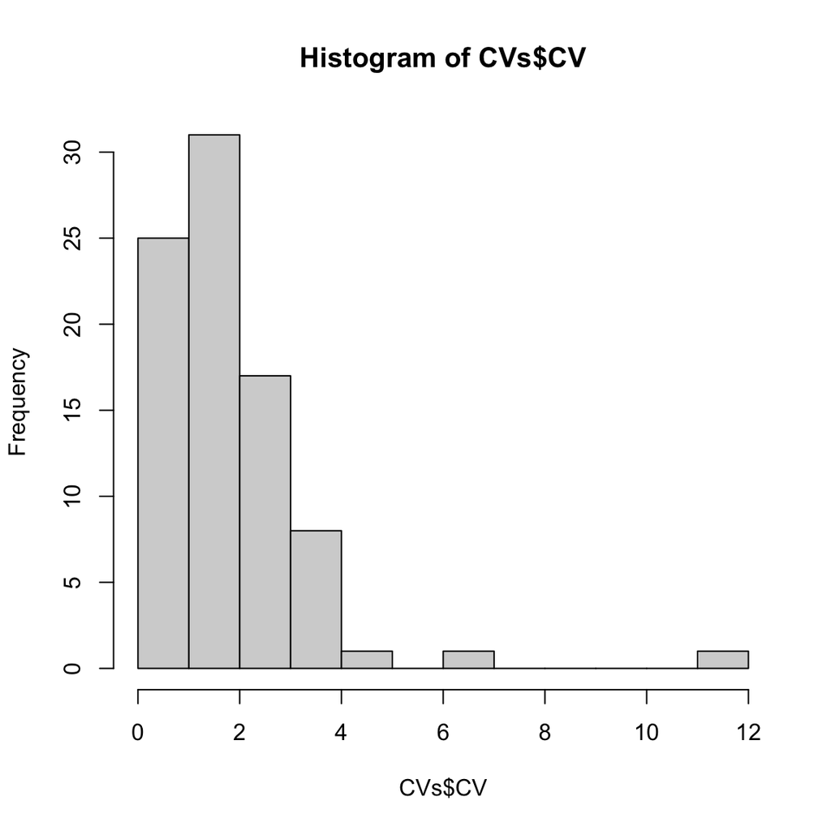

```r
hist(CVs$CV)
```

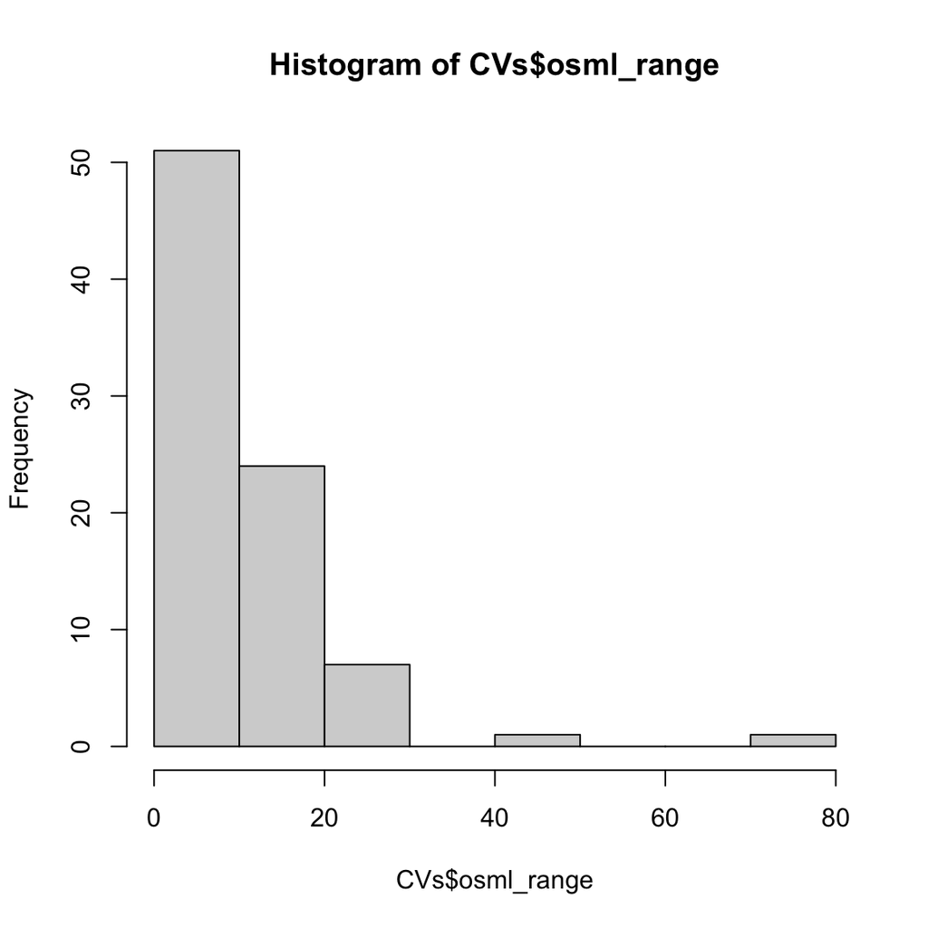

```r
hist(CVs$osml_range)
```

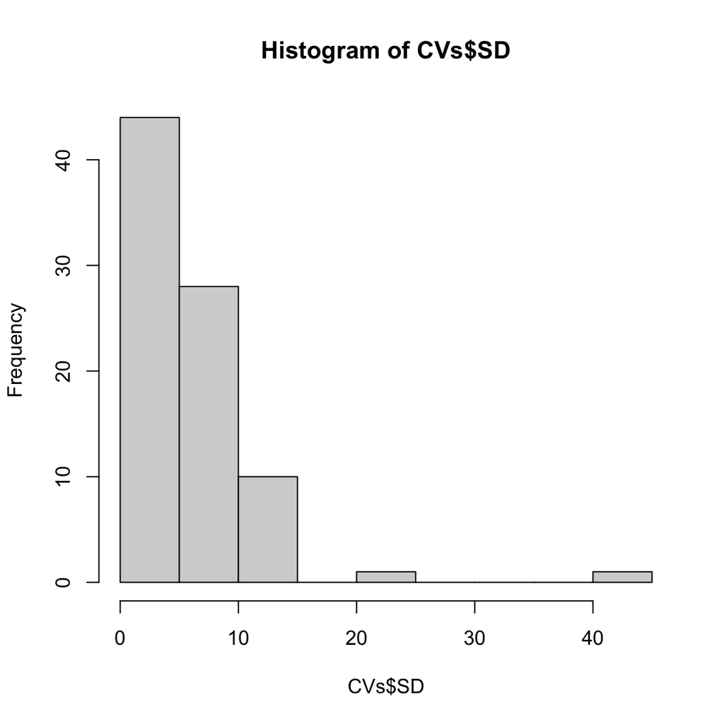

```r
hist(CVs$SD)
```

All of the ranges >20 mmosm are not good, But only one CV> 10, so yay!

## Find Outliers

```r
outliers_found <- osml_reps %>%
  group_by(sample_ID) %>%
  summarise(outs = boxplot.stats(osmolality_mmol_kg)$out) %>%
  mutate(outlier = "Yes")
```

The good news is that there were no outliers for any tech rep groups, as assessed by IQR!

Double check the two rep groups with the highest CVs and super high ranges, both of which are outside the distribution of CV, range, and SD for all tech rep sets:

```r
CVs %>%
  dplyr::filter(CV > 5)
```

```
## # A tibble: 2 × 7
##   sample_ID  mean    SD    CV   min   max osml_range
##   <fct>     <dbl> <dbl> <dbl> <dbl> <dbl>      <dbl>
## 1 push-RM-1  361.  40.7 11.3    333   408         75
## 2 push-RT-3  338   21.6  6.40   320   362         42
```

```r
osml_reps %>%
  dplyr::filter(sample_ID == "push-RM-1")
```

```
##   date_osmom_run time_osmom_run sample_ID Entered.by Checked.by    X
## 1        6/12/23          14:33 push-RM-1       Nemo       <NA> <NA>
## 2        6/12/23          14:33 push-RM-1       Nemo       <NA> <NA>
## 3        6/12/23          14:33 push-RM-1       Nemo       <NA> <NA>
##   replicate_no osmolality_mmol_kg
## 1         rep1                408
## 2         rep2                333
## 3         rep3                343
```

```r
osml_reps %>%
  dplyr::filter(sample_ID == "push-RT-3")
```

```
##   date_osmom_run time_osmom_run sample_ID Entered.by Checked.by    X
## 1        5/17/23          11:30 push-RT-3       Nemo      Robin <NA>
## 2        5/17/23          11:30 push-RT-3       Nemo      Robin <NA>
## 3        5/17/23          11:30 push-RT-3       Nemo      Robin <NA>
##   replicate_no osmolality_mmol_kg
## 1         rep1                320
## 2         rep2                332
## 3         rep3                362
```

What is the standard deviation of these two tech rep groups with versus without the one rep that’s very different?

```r
sd(c(408, 333, 343)) # sd all 3
```

```
## [1] 40.72264
```

```r
sd(c(333, 343)) # sd only two
```

```
## [1] 7.071068
```

```r
40/7 # how many x geater
```

```
## [1] 5.714286
```

```r
(408-343)/7.1 # how many SDs away from others in the set
```

```
## [1] 9.15493
```

```r
sd(c(320, 332, 362))
```

```
## [1] 21.63331
```

```r
sd(c(320, 332))
```

```
## [1] 8.485281
```

```r
21/8
```

```
## [1] 2.625
```

```r
(362-332)/8.5
```

```
## [1] 3.529412
```

The unofficial “outliers” increase SD by 2.6-5.7x! And, without them, their SDs would fit into the overall distribution of SDs.

In both cases, I think the one replicate very different from the others should be removed.

## Remove Outliers

This code chunk removes two technical replicate values. You can know it does so by removing (and replacing) the “!” within each filter, and by comparing the number of rows for ‘osml_reps’ versus ‘outliers_removed’.

```r
outliers_removed <- osml_reps %>%
  group_by(sample_ID) %>%
  dplyr::filter(!(sample_ID == "push-RT-3" & osmolality_mmol_kg == 362)) %>%
  dplyr::filter(!(sample_ID == "push-RM-1" & osmolality_mmol_kg == 408))
```

## Average Remaining Replicates

Now that the two unofficial outliers have been removed from the technical replicates, we will average the technical replicates for each sample.

```r
osml_means <- outliers_removed %>%
  group_by(sample_ID) %>%
  summarise(osmolality_mmol_kg_mean = mean(osmolality_mmol_kg, na.rm = TRUE))

summary(osml_means)
```

```
##      sample_ID  osmolality_mmol_kg_mean
##  0-1      : 1   Min.   :313.3
##  0-2      : 1   1st Qu.:323.7
##  0-3      : 1   Median :331.7
##  0-4      : 1   Mean   :336.2
##  0-5      : 1   3rd Qu.:338.3
##  push-FM-1: 1   Max.   :429.0
##  (Other)  :79
```

# Samples

Before we go on to analysis, let’s check the distribution of sample values (the averaged technical replicates).

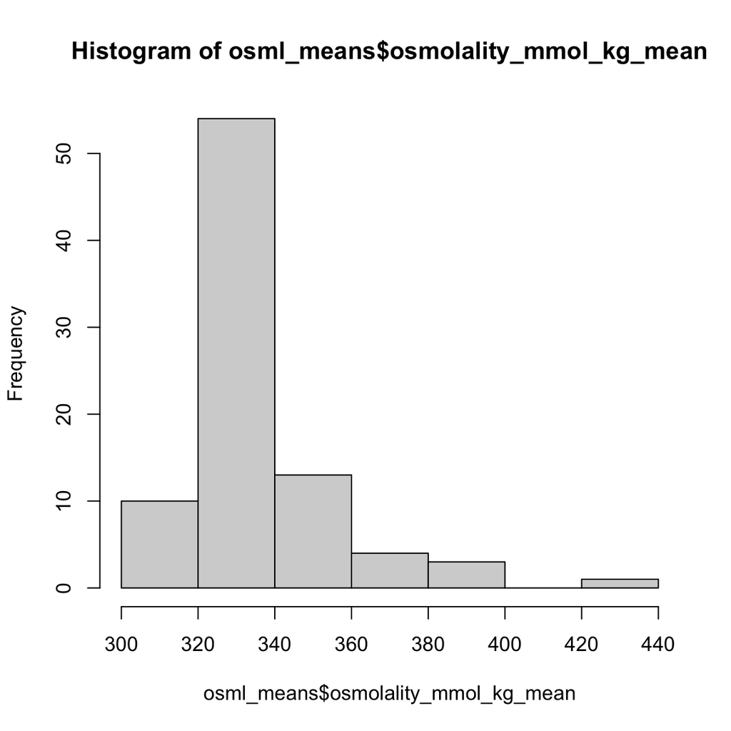

```r
hist(osml_means$osmolality_mmol_kg_mean)
```

Only one sample was >400. Investigate:

```r
osml_means %>%
  dplyr::filter(osmolality_mmol_kg_mean > 400)
```

```
## # A tibble: 1 × 2
##   sample_ID  osmolality_mmol_kg_mean
##   <fct>                        <dbl>
## 1 screw-RM-1                     429
```

```r
osml_reps %>%
  dplyr::filter(sample_ID == "screw-RM-1")
```

```
##   date_osmom_run time_osmom_run  sample_ID Entered.by Checked.by    X
## 1        6/12/23          16:40 screw-RM-1       Nemo       <NA> <NA>
## 2        6/12/23          16:40 screw-RM-1       Nemo       <NA> <NA>
## 3        6/12/23          16:40 screw-RM-1       Nemo       <NA> <NA>
##   replicate_no osmolality_mmol_kg
## 1         rep1                426
## 2         rep2                426
## 3         rep3                435
```

```r
osml_means %>%
  dplyr::filter(substr(sample_ID, 1, 8) == "screw-RM")
```

```
## # A tibble: 5 × 2
##   sample_ID  osmolality_mmol_kg_mean
##   <fct>                        <dbl>
## 1 screw-RM-1                    429
## 2 screw-RM-2                    371
## 3 screw-RM-3                    387.
## 4 screw-RM-4                    387.
## 5 screw-RM-5                    383.
```

check SD difference:

```r
sd(c(382, 386, 386, 371, 429))
```

```
## [1] 22.21936
```

```r
sd(c(382, 386, 386, 371))
```

```
## [1] 7.088723
```

```r
(429-386)/7.1 # how many SDs away from others in the set
```

```
## [1] 6.056338
```

It’s so far outside the distribution of the samples in its set, and outside the distribution of samples overall, it should be removed.

```r
osml_means_clean <- osml_means %>%
  dplyr::filter(osmolality_mmol_kg_mean < 400)
```

# Export

First, format some labeling.

```r
save <- osml_means_clean %>%
  dplyr::filter(substr(sample_ID, 1, 1) != "0")
fix <- osml_means_clean %>%
  dplyr::filter(substr(sample_ID, 1, 1) == "0") %>%
  mutate(sample_ID = paste("push", sample_ID, sep = "-"))

osml_means_labeled <- fix %>%
  rbind(save) %>%
  separate(sample_ID, into = c("tube", "storage", "sample_no"), sep = "-") %>%
  mutate(tube = factor(tube),
         storage = factor(storage),
         sample_no = factor(sample_no))

summary(osml_means_labeled)
```

```
##     tube       storage   sample_no osmolality_mmol_kg_mean
##  push :45   FM     :10   1:16      Min.   :313.3
##  screw:39   FT     :10   2:17      1st Qu.:323.7
##             FV     :10   3:17      Median :331.7
##             FW     :10   4:17      Mean   :335.1
##             RT     :10   5:17      3rd Qu.:338.3
##             RV     :10             Max.   :386.7
##             (Other):24
```

```r
unique(osml_means_labeled$storage)
```

```
## [1] 0  FM FT FV FW RM RT RV RW
## Levels: 0 FM FT FV FW RM RT RV RW
```

The storage codes are as follows:

temperature: - R = refridgerator (3-5C) - F = freezer (-18C)

time: - T = 48 hours *we previously planned on 24h, but the osmometer decided otherwise* - V = 72-86 hours - W = 1 week - M = 1 month

```r
osml_means_pretty <- osml_means_labeled %>%
  mutate(Temperature = case_when(substr(storage, 1, 1) == "R" ~ "Refrigerator",
                                 substr(storage, 1, 1) == "F" ~ "Freezer",
                                 storage == "0" ~ "None"),
         Days = case_when(storage == "0" ~ "0",
                          substr(storage, 2, 2) == "T" ~ "2",
                          substr(storage, 2, 2) == "V" ~ "3-4",
                          substr(storage, 2, 2) == "W" ~ "7",
                          substr(storage, 2, 2) == "M" ~ "28-29")) %>%
  mutate(Temperature = factor(Temperature,
                              levels = c("None", "Refrigerator", "Freezer")),
         Days = factor(Days,
                       levels = c("0", "2", "3-4", "7", "28-29")
                       ))
summary(osml_means_pretty)
```

```
##     tube       storage   sample_no osmolality_mmol_kg_mean       Temperature
##  push :45   FM     :10   1:16      Min.   :313.3           None        : 5
##  screw:39   FT     :10   2:17      1st Qu.:323.7           Refrigerator:39
##             FV     :10   3:17      Median :331.7           Freezer     :40
##             FW     :10   4:17      Mean   :335.1
##             RT     :10   5:17      3rd Qu.:338.3
##             RV     :10             Max.   :386.7
##             (Other):24
##     Days
##  0    : 5
##  2    :20
##  3-4  :20
##  7    :20
##  28-29:19
##
##
```

Then export the df to be used in a different Rmd for stats and figures:

```r
write_rds(osml_means_pretty, "./data/osml_means_clean.RDS")
```

# Reporting

Two technical replicates and one sample were removed because they were each >3 SDs away from the rest of the distribution.